# multi_gsea

```r
library(multigsea)
library(org.Mm.eg.db)
library(tidyverse)
library(tidyheatmaps)
library(ggrepel)
```

MultiGSEA provides a series of tools to calculate, visualise and analyse the Gene Set Enrichment Analysis (GSEA) results from multiple experimental results.

# Starting Data

The start point for this analysis is a tibble containing 3 or more columns. One must be a called `Genes` and contain the gene symbols from the species you’re using. All other columns must be named after samples in your experiment and must contain the numeric values for each of the genes. Commonly these values will be some form of difference value (shrunken log2 Fold changes for example), but can be any suitably behaving number for GSEA analysis.

```r
system.file("multigsea_test_data.tsv", package="multigsea") -> example_data_file
read_delim(example_data_file) -> example_data

head(example_data)
```

```
#> # A tibble: 6 × 3
#>   Genes     Early    Late
#>   <chr>     <dbl>   <dbl>
#> 1 Rp1       0.706  195.
#> 2 Sox17    -9.96   -15.3
#> 3 Mrpl15  -84.9   -175.
#> 4 Lypla1  -46.2     -8.90
#> 5 Tcea1   -39.1   -183.
#> 6 Atp6v1h  35.9    -36.0
```

In this example we have two samples, `Early` and `Late`. The values in the tibble do not need to be sorted.

The names in the `Gene` column must be unique. You will get a warning if any of the values in the quantitative columns contain tied values, but this will not prevent the analysis from running.

# Calculating GSEA results

The first step in the analysis is to calculate a full set of GSEA results. For this you will need to specify a Bioconductor genome, and you will need to decide which branch(es) of the Gene Ontology you want to use.

```r
run_multi_gsea(example_data, org = org.Mm.eg.db) -> gsea_results
```

```
#>
#> using 'fgsea' for GSEA analysis, please cite Korotkevich et al (2019).
#> preparing geneSet collections...
#> GSEA analysis...
#> leading edge analysis...
#> done...
#> using 'fgsea' for GSEA analysis, please cite Korotkevich et al (2019).
#> preparing geneSet collections...
#> GSEA analysis...
#> leading edge analysis...
#> done...
```

```r
head(gsea_results)
```

```
#> # A tibble: 6 × 13
#>   ID        Condition Description setSize enrichmentScore   NES  pvalue p.adjust
#>   <chr>     <chr>     <chr>         <int>           <dbl> <dbl>   <dbl>    <dbl>
#> 1 GO:00193… Early     arachidoni…      39          -0.743 -2.27 9.35e-8  9.35e-8
#> 2 GO:00161… Early     diterpenoi…      39          -0.729 -2.23 3.01e-7  3.01e-7
#> 3 GO:00015… Early     retinoid m…      37          -0.720 -2.17 5.56e-7  5.56e-7
#> 4 GO:00197… Early     secondary …      35          -0.737 -2.19 5.60e-7  5.60e-7
#> 5 GO:00421… Early     xenobiotic…      20          -0.829 -2.18 8.72e-7  8.72e-7
#> 6 GO:00193… Early     epoxygenas…      18          -0.842 -2.16 1.07e-6  1.07e-6
#> # ℹ 5 more variables: qvalue <dbl>, rank <dbl>, leading_edge <chr>,
#> #   core_enrichment <chr>, Directional_Phred <dbl>
```

You have the full GSEA result for each GO category, for each sample in your data.

# Applying Filters

We don’t want to look at all of the GSEA results as many of them will be uninteresting. Instead we will filter to keep only those which are interesting in at least one of the conditions.

```r
filter_multi_gsea(gsea_results, nes_cutoff = 1, fdr_cutoff = 0.05) -> filtered_gsea_results
```

## Viewing Results

You can look at the distribution of enrichment score values, and levels of significance between the datasets

### Distribution of NES values

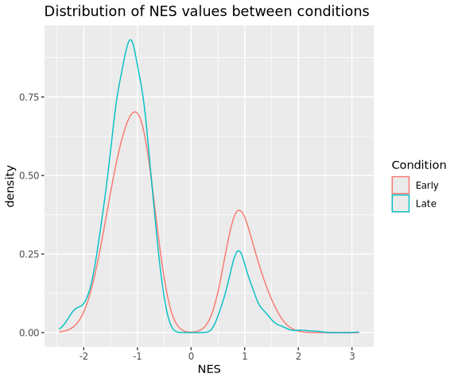

```r
gsea_results |>
  ggplot(aes(x=NES, colour=Condition)) +
  geom_density() +
  ggtitle("Distribution of NES values between conditions")
```

Let’s do the same thing after filtering

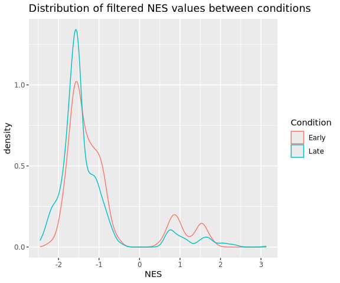

```r
filtered_gsea_results |>
  ggplot(aes(x=NES, colour=Condition)) +
  geom_density() +
  ggtitle("Distribution of filtered NES values between conditions")
```

### Distribution of Directional PHRED values

We can also plot PHRED scores where we convert the scores with a negative NES to give a negative PHRED

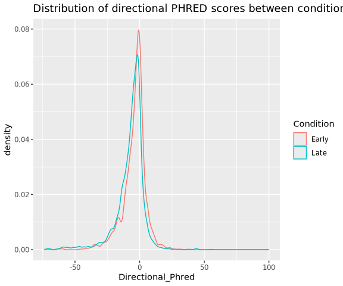

```r
gsea_results |>
  ggplot(aes(x=Directional_Phred, colour=Condition)) +
  geom_density() +
  ggtitle("Distribution of directional PHRED scores between conditions")
```

Again, we can do the same thing with the filtered data.

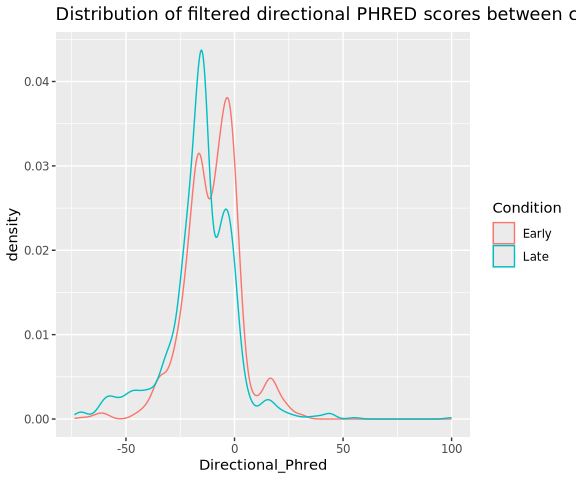

```r
filtered_gsea_results |>
  ggplot(aes(x=Directional_Phred, colour=Condition)) +
  geom_density() +
  ggtitle("Distribution of filtered directional PHRED scores between conditions")
```

# Comparison between conditions

Let’s take a look at the comparison of the metrics between the two conditions in this dataset

## Directional Phred Scatterplot

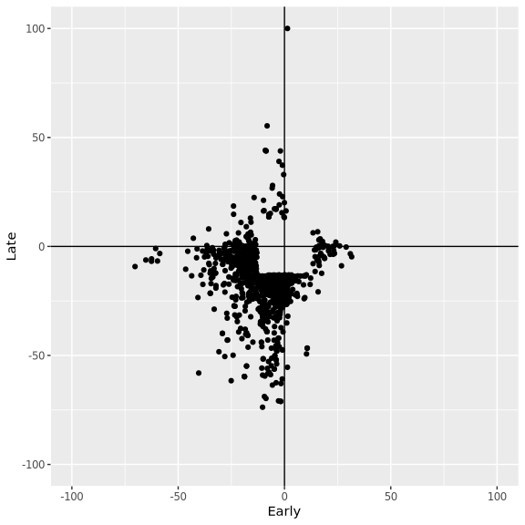

```r
filtered_gsea_results |>
  condition_gsea_scatterplot("Early","Late", metric="Directional_Phred")
```

## NES Scatterplot

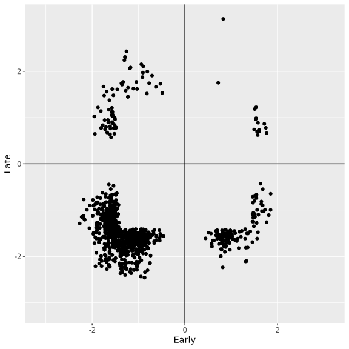

```r
filtered_gsea_results |>
  condition_gsea_scatterplot("Early","Late", metric="NES")
```

# Finding categories which change between conditions

Now we can further filter the results to get those which change in an interesting way between conditions

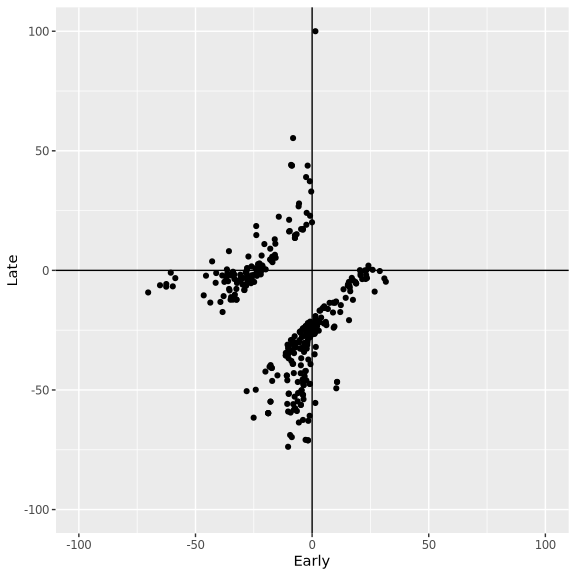

```r
find_condition_differences(
  filtered_gsea_results,
  "Early",
  "Late",
  cutoff = 20,
  metric="Directional_Phred"
) -> early_late_gsea_differences

early_late_gsea_differences |>
  condition_gsea_scatterplot("Early","Late", metric="Directional_Phred")
```

# Clustering the terms

Let’s see how many different terms we’re still dealing with here.

```r
early_late_gsea_differences %>%
  distinct(ID) %>%
  nrow()
```

```
#> [1] 332
```

## Calculating the overlaps between terms

So we have over hundreds of terms still which is too many to deal with. Many of those terms will be highly overlapping in their gene content, so we can cluster them based on this to get a smaller subset of distinct subgroups.

```r
create_category_overlap_matrix(early_late_gsea_differences, max_categories = 400) -> early_late_category_overlap_matrix
early_late_category_overlap_matrix %>%
  arrange(desc(overlap)) %>%
  head()
```

```
#> # A tibble: 6 × 3
#> # Rowwise:
#>   ID2        ID1        overlap
#>   <chr>      <chr>        <dbl>
#> 1 GO:0001580 GO:0050912     100
#> 2 GO:0001774 GO:0002269     100
#> 3 GO:0001787 GO:0032817     100
#> 4 GO:0001794 GO:0001796     100
#> 5 GO:0001794 GO:0001798     100
#> 6 GO:0001794 GO:0002445     100
```

## Plotting the overlaps

We can see categories which highly overlap, we can look at this.

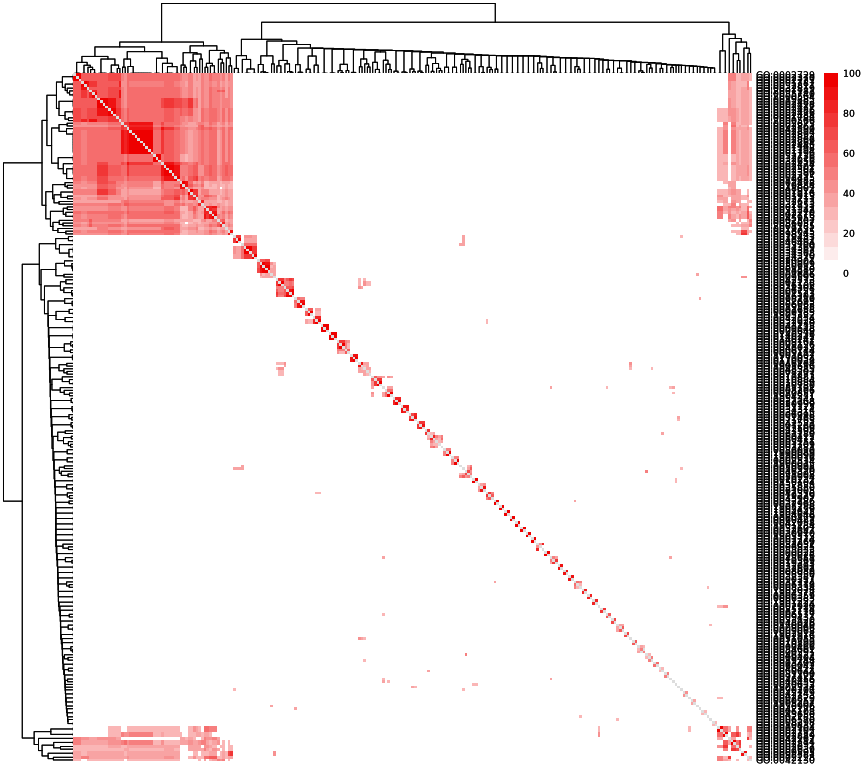

```r
plot_category_overlap_heatmap(early_late_category_overlap_matrix, minoverlap = 30)
```

We can see groups with different levels of similarity, but that there is one big group which is highly connected.

## Calling clusters

We can now build groups out of the terms

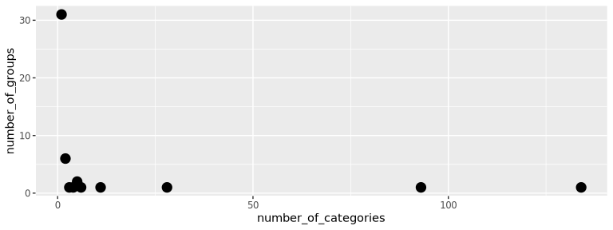

```r
create_gsea_groups(early_late_category_overlap_matrix, minoverlap = 30) -> early_late_gsea_groups


early_late_gsea_groups %>%
  group_by(Group) %>%
  count(name = "number_of_categories") %>%
  group_by(number_of_categories) %>%
  count(name="number_of_groups") %>%
  ggplot(aes(x=number_of_categories, y=number_of_groups)) +
  geom_point(size=4)
```

We have quite a lot of categories with just one group in it, but also a few which have many (over 100 in the largest case)

## Apply groups to differences

```r
early_late_gsea_differences %>%
  left_join(early_late_gsea_groups) %>%
  select(ID,Description, Group, Condition, Directional_Phred) %>%
  pivot_wider(
    names_from=Condition,
    values_from=Directional_Phred
  ) %>%
  arrange(desc(abs(Late-Early))) %>%
  group_by(Group) %>%
  mutate(Group_Size=n()) %>%
  slice(1) %>%
  ungroup() -> early_late_grouped_results
early_late_grouped_results %>% filter(Group_Size>1)
```

```
#> # A tibble: 15 × 6
#>    ID         Description                        Group  Early    Late Group_Size
#>    <chr>      <chr>                              <chr>  <dbl>   <dbl>      <int>
#>  1 GO:0019236 response to pheromone              Grou…   1.41 100            134
#>  2 GO:0006882 intracellular zinc ion homeostasis Grou…   1.45 -22.5            2
#>  3 GO:0090026 positive regulation of monocyte c… Grou… -16.0   13.0            2
#>  4 GO:1902807 negative regulation of cell cycle… Grou…   1.44 -25.0            2
#>  5 GO:0042058 regulation of epidermal growth fa… Grou…  -3.24 -30.3            2
#>  6 GO:0055081 monoatomic anion homeostasis       Grou… -28.5   -0.830          2
#>  7 GO:0090317 negative regulation of intracellu… Grou…  23.0   -3.60           2
#>  8 GO:0032819 positive regulation of natural ki… Grou…  -8.08 -55.9            6
#>  9 GO:0042908 xenobiotic transport               Grou… -36.8   -3.14          28
#> 10 GO:0002716 negative regulation of natural ki… Grou…  -1.76 -71.1           93
#> 11 GO:0036010 protein localization to endosome   Grou…   8.96 -17.6            5
#> 12 GO:0045953 negative regulation of natural ki… Grou…  -1.76 -71.1           11
#> 13 GO:0140236 translation at presynapse          Grou…  10.4  -49.3            4
#> 14 GO:0042311 vasodilation                       Grou…  -7.65 -32.0            5
#> 15 GO:0034497 protein localization to phagophor… Grou…  31.0   -3.36           3
```

## Plotting grouped results

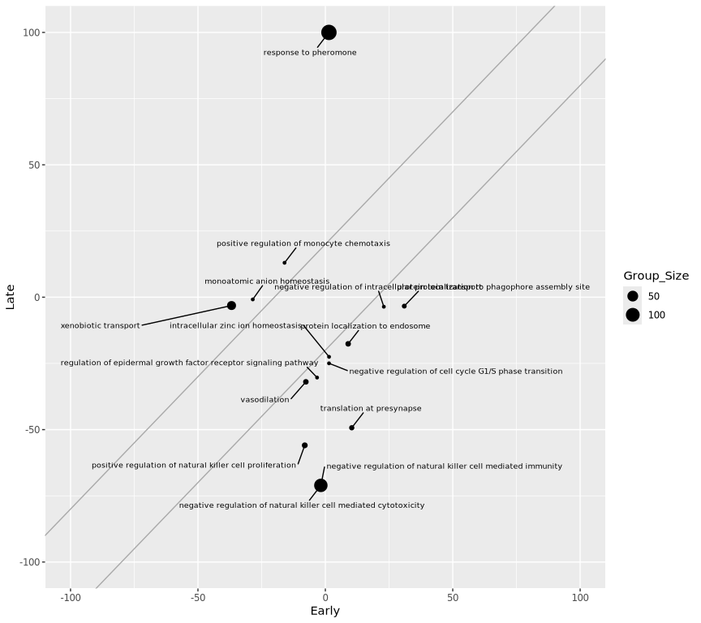

```r
early_late_grouped_results %>%
  filter(Group_Size>1) %>%
  ggplot(aes(x=Early, y=Late, size=Group_Size, label=Description)) +
  geom_point() +
  geom_abline(slope=1,intercept=c(-20,20), color="darkgrey") +
  geom_text_repel(size=2.5, box.padding = 1) +
  coord_cartesian(xlim=c(-100,100), ylim=c(-100,100))
```

# Plotting original data

Finally let’s plot out the fold changes for all of the genes in the different groups we have selected.

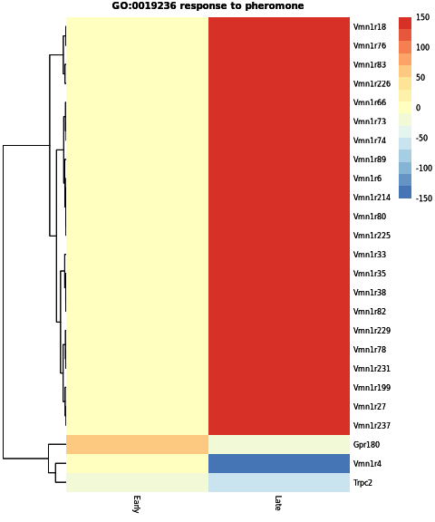

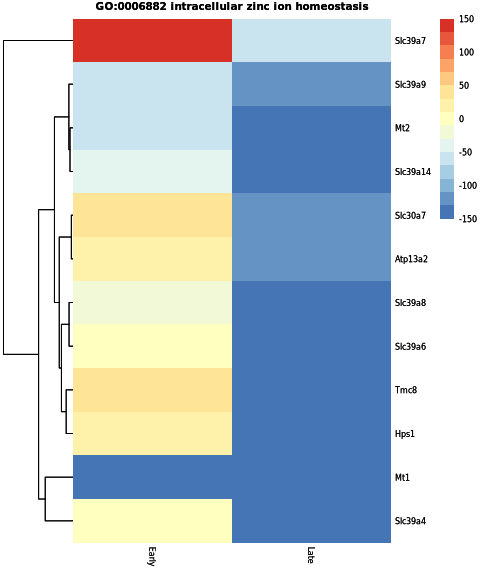

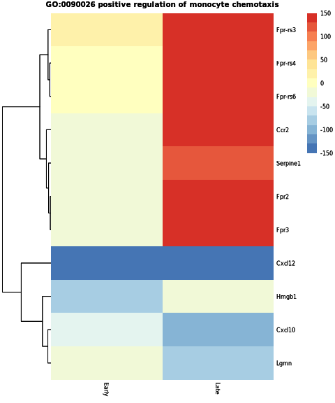

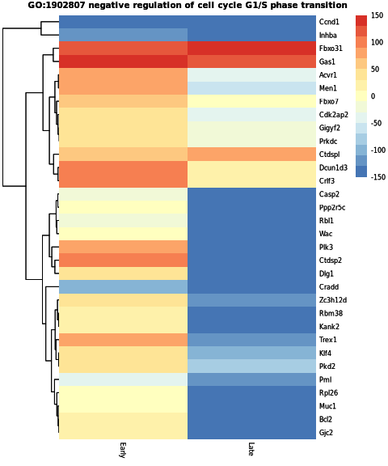

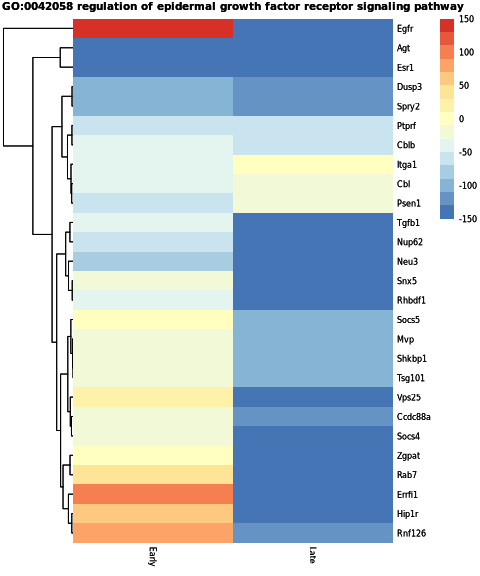

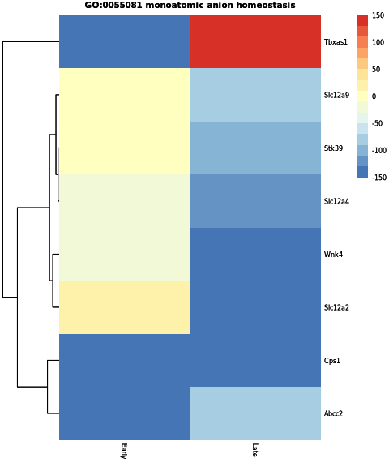

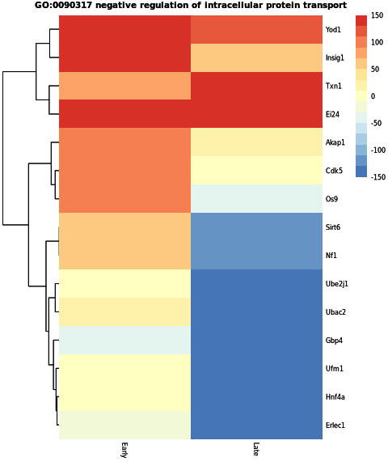

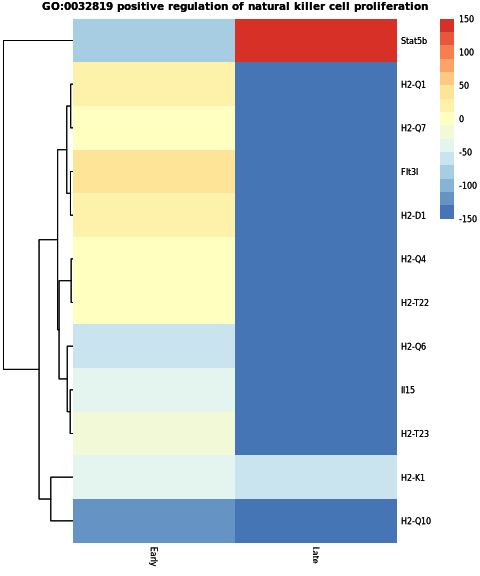

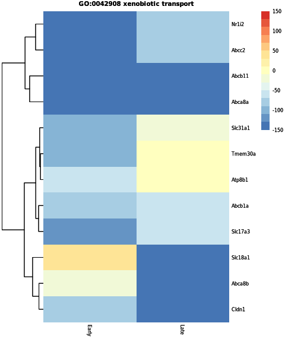

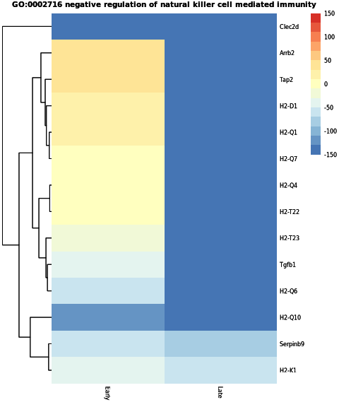

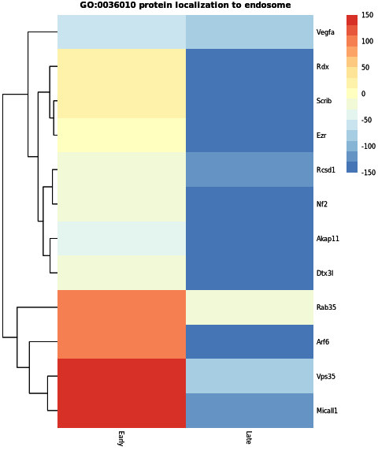

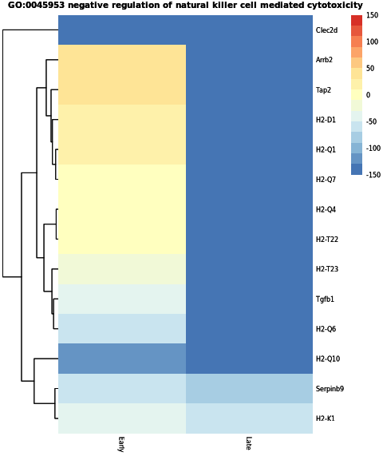

[3 more figures not shown]

```r
for (category in early_late_grouped_results %>% filter(Group_Size>1) %>% pull(ID)) {

  plot_values_for_category(early_late_gsea_differences, example_data, category, min_value = -150, max_value = 150) -> category_heatmap

  print(category_heatmap)
}
```

This plot shows only the genes which were in the leading edge subset in one of the categories so other genes from the set may be present in the data. You should be able to see a representation of the reason that these categories changed through.